# Clase 7. Aplicacion AR(p)

## Función de Autocorrelación Parcial

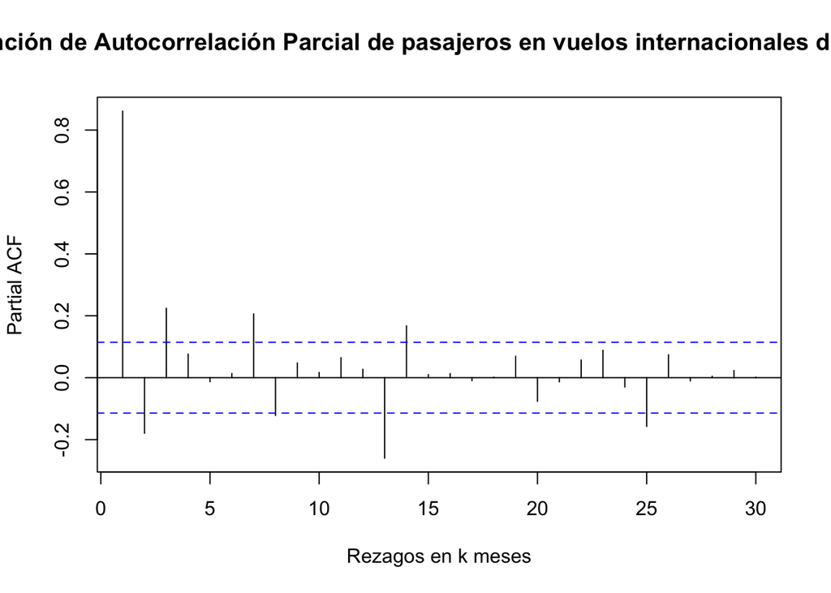

```r
pacf(LPax_Int[1:294], lag.max = 30,
     main = "Función de Autocorrelación Parcial de pasajeros en vuelos internacionales de salida",
     xlab = 'Rezagos en k meses')
```

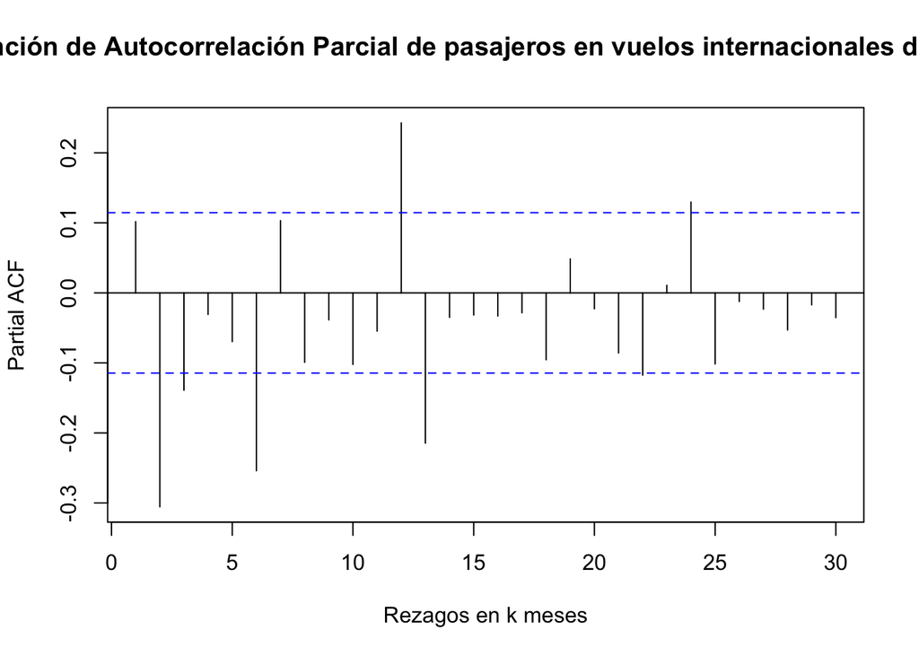

```r
pacf(DLPax_Int[2:294], lag.max = 30,
     main = "Función de Autocorrelación Parcial de pasajeros en vuelos internacionales de salida",
     xlab = 'Rezagos en k meses')
```

## Ejercicios

1. Estima AR(p) para p = 1, 2, …, 8 sobre `Pax_Nal`. Construye una tabla con AIC y BIC para cada p. ¿Coinciden ambos criterios en el orden óptimo?
2. ¿Por qué BIC tiende a seleccionar modelos más parsimoniosos que AIC? Muestra matemáticamente la diferencia en el término de penalización para n = 200 observaciones.
3. Verifica la condición de estacionariedad para el AR(p) seleccionado graficando sus raíces características con `plot.armaroots()`.